# Spotify Dataset: Detect Trends, Data Analysis & Visualization

**Author:** Saunak Sinha Ray  
**Email:** saunaksray@gmail.com  
**Website:** Upcoming

### **1. Introduction**

**This project analyzes data from the popular music streaming platform, Spotify. The following analyses types have been conducted along with appropriate viosualizations:**

- *Descriptive Analysis*
- *Comparative Analysis*
- *Trend Analysis*
- *Predictive Analysis*
- *Exploratory Analysis*
- *Behavorial ANalysis*
- *Segment Analysis*

Hope you have fun exploring the notebook! 😊

After downloading the raw dataset, I ran a check on MS-Excel (using Power Query) to clean and organize the data and check for errors and duplicates. After post-processing, we start with the required steps, first by importing all neccesary libraries and loading the first few rows of the dataframe

```python
import pandas as pd
import numpy as np
import matplotlib.pyplot as plt
import seaborn as sns

# loading the dataset
file_path = r'C:\Users\sauna\OneDrive - České vysoké učení technické v Praze\Kaggle Datasets\spotify-data.csv'
spotify_data = pd.read_csv(file_path)
spotify_data.head()
```

|  | id | name | artists | duration_ms | release_date | year | acousticness | danceability | energy | instrumentalness | liveness | loudness | speechiness | tempo | valence | mode | key | popularity | explicit |
| --- | --- | --- | --- | --- | --- | --- | --- | --- | --- | --- | --- | --- | --- | --- | --- | --- | --- | --- | --- |
| 0 | 6KbQ3uYMLKb5jDxLF7wYDD | Singende Bataillone 1. Teil | ['Carl Woitschach'] | 158648 | 1928 | 1928 | 0.995 | 0.708 | 0.1950 | 0.563 | 0.1510 | -12.428 | 0.0506 | 118.469 | 0.7790 | 1 | 10 | 0 | 0 |
| 1 | 6KuQTIu1KoTTkLXKrwlLPV | Fantasiestücke, Op. 111: Più tosto lento | ['Robert Schumann', 'Vladimir Horowitz'] | 282133 | 1928 | 1928 | 0.994 | 0.379 | 0.0135 | 0.901 | 0.0763 | -28.454 | 0.0462 | 83.972 | 0.0767 | 1 | 8 | 0 | 0 |
| 2 | 6L63VW0PibdM1HDSBoqnoM | Chapter 1.18 - Zamek kaniowski | ['Seweryn Goszczyński'] | 104300 | 1928 | 1928 | 0.604 | 0.749 | 0.2200 | 0.000 | 0.1190 | -19.924 | 0.9290 | 107.177 | 0.8800 | 0 | 5 | 0 | 0 |
| 3 | 6M94FkXd15sOAOQYRnWPN8 | Bebamos Juntos - Instrumental (Remasterizado) | ['Francisco Canaro'] | 180760 | 9/25/28 | 1928 | 0.995 | 0.781 | 0.1300 | 0.887 | 0.1110 | -14.734 | 0.0926 | 108.003 | 0.7200 | 0 | 1 | 0 | 0 |
| 4 | 6N6tiFZ9vLTSOIxkj8qKrd | Polonaise-Fantaisie in A-Flat Major, Op. 61 | ['Frédéric Chopin', 'Vladimir Horowitz'] | 687733 | 1928 | 1928 | 0.990 | 0.210 | 0.2040 | 0.908 | 0.0980 | -16.829 | 0.0424 | 62.149 | 0.0693 | 1 | 11 | 1 | 0 |

```python
from IPython.display import display

# Compute Descriptive Statistics
desc_stats = spotify_data.describe().T  # Transpose for better readability

# Add extra checks
desc_stats['missing_values'] = spotify_data.isnull().sum()
desc_stats['unique_values'] = spotify_data.nunique()
desc_stats['dtype'] = spotify_data.dtypes

# Rename index for better readability
desc_stats.index.name = 'Feature'

# Display Descriptive Statistics Table (No Button, Direct Output)
print("\n **Descriptive Statistics Table**")
display(desc_stats)
```

```
 **Descriptive Statistics Table**
```

| Feature | count | mean | std | min | 25% | 50% | 75% | max | missing_values | unique_values | dtype |
| --- | --- | --- | --- | --- | --- | --- | --- | --- | --- | --- | --- |
| duration_ms | 169909.0 | 231406.158973 | 121321.923219 | 5108.0 | 171040.0000 | 208600.000000 | 262960.0000 | 5403500.000 | 0 | 50212 | int64 |
| year | 169909.0 | 1977.223231 | 25.593168 | 1921.0 | 1957.0000 | 1978.000000 | 1999.0000 | 2020.000 | 0 | 100 | int64 |
| acousticness | 169909.0 | 0.493214 | 0.376627 | 0.0 | 0.0945 | 0.492000 | 0.8880 | 0.996 | 0 | 4714 | float64 |
| danceability | 169909.0 | 0.538150 | 0.175346 | 0.0 | 0.4170 | 0.548000 | 0.6670 | 0.988 | 0 | 1232 | float64 |
| energy | 169909.0 | 0.488593 | 0.267390 | 0.0 | 0.2630 | 0.481000 | 0.7100 | 1.000 | 0 | 2332 | float64 |
| instrumentalness | 169909.0 | 0.161937 | 0.309329 | 0.0 | 0.0000 | 0.000204 | 0.0868 | 1.000 | 0 | 5401 | float64 |
| liveness | 169909.0 | 0.206690 | 0.176796 | 0.0 | 0.0984 | 0.135000 | 0.2630 | 1.000 | 0 | 1741 | float64 |
| loudness | 169909.0 | -11.370289 | 5.666765 | -60.0 | -14.4700 | -10.474000 | -7.1180 | 3.855 | 0 | 25313 | float64 |
| speechiness | 169909.0 | 0.094058 | 0.149937 | 0.0 | 0.0349 | 0.045000 | 0.0754 | 0.969 | 0 | 1628 | float64 |
| tempo | 169909.0 | 116.948017 | 30.726937 | 0.0 | 93.5160 | 114.778000 | 135.7120 | 244.091 | 0 | 84548 | float64 |
| valence | 169909.0 | 0.532095 | 0.262408 | 0.0 | 0.3220 | 0.544000 | 0.7490 | 1.000 | 0 | 1739 | float64 |
| mode | 169909.0 | 0.708556 | 0.454429 | 0.0 | 0.0000 | 1.000000 | 1.0000 | 1.000 | 0 | 2 | int64 |
| key | 169909.0 | 5.200519 | 3.515257 | 0.0 | 2.0000 | 5.000000 | 8.0000 | 11.000 | 0 | 12 | int64 |
| popularity | 169909.0 | 31.556610 | 21.582614 | 0.0 | 12.0000 | 33.000000 | 48.0000 | 100.000 | 0 | 100 | int64 |
| explicit | 169909.0 | 0.084863 | 0.278679 | 0.0 | 0.0000 | 0.000000 | 0.0000 | 1.000 | 0 | 2 | int64 |

- Visualization of data using histograms, probability distribution, and IQR ranges using box plots

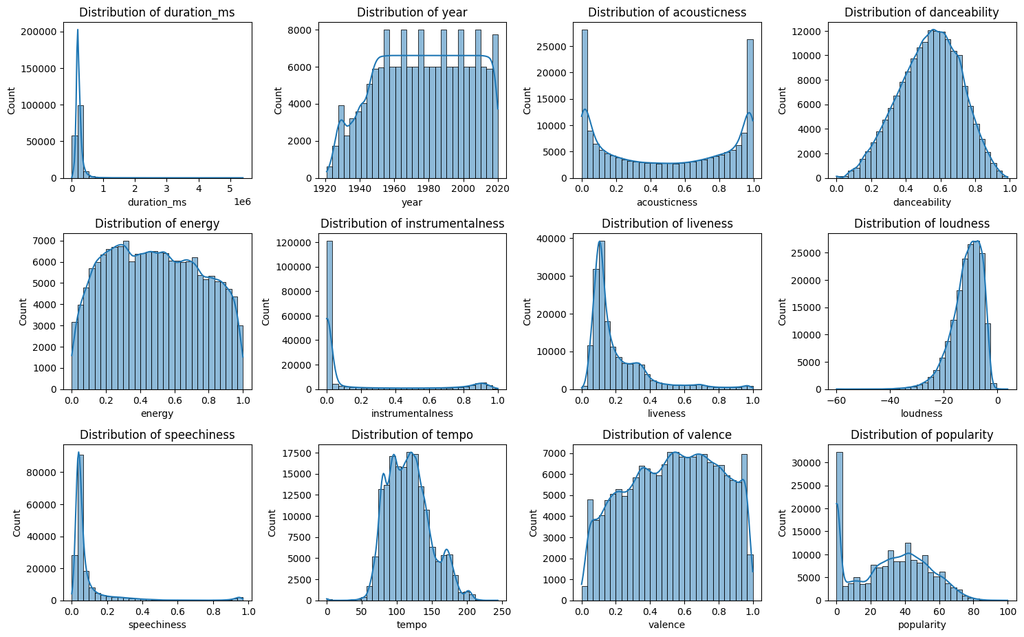

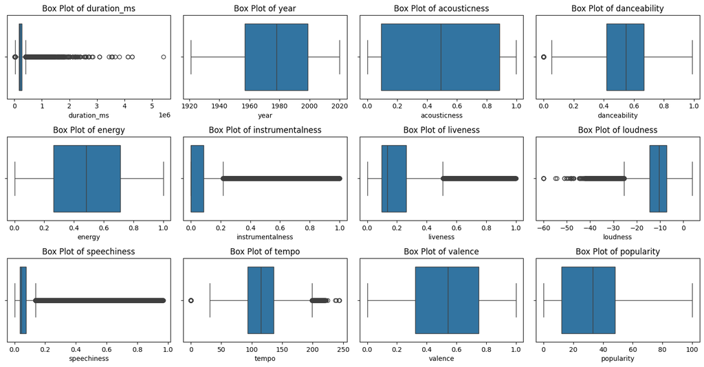

```python
%matplotlib inline
# Set up the figure size
plt.figure(figsize=(15, 12))

num_columns = ['duration_ms', 'year', 'acousticness', 'danceability', 'energy',
               'instrumentalness', 'liveness', 'loudness', 'speechiness', 'tempo',
               'valence', 'popularity']

# Loop through columns and create histograms
for i, col in enumerate(num_columns, 1):
    plt.subplot(4, 4, i)  # Create a grid of subplots
    sns.histplot(spotify_data[col], bins=30, kde=True)
    plt.title(f'Distribution of {col}')

plt.tight_layout()  # Adjust layout for better spacing
plt.show()

# boxplots and checking for outliers
plt.figure(figsize=(15, 10))

for i, col in enumerate(num_columns, 1):
    plt.subplot(4, 4, i)
    sns.boxplot(x=spotify_data[col])
    plt.title(f'Box Plot of {col}')

plt.tight_layout()
plt.show()
```

### **Lets figure out the top ten tracks and artists in the datset**

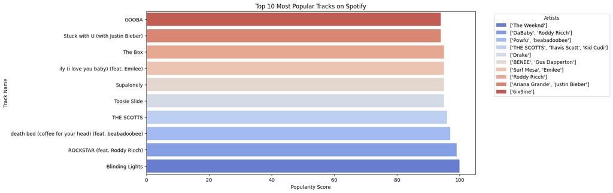

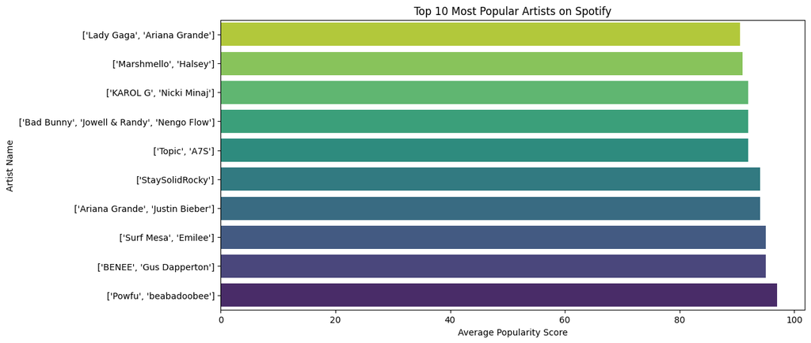

```python
# Define the Top 10 Tracks & Artists
top_tracks = spotify_data[['name', 'artists', 'popularity']].sort_values(by='popularity', ascending=False).head(10)

top_artists = spotify_data.groupby('artists')['popularity'].mean().reset_index()
top_artists = top_artists.sort_values(by='popularity', ascending=False).head(10)

# Top 10 Tracks Visualization
plt.figure(figsize=(12,6))
sns.barplot(data=top_tracks, y='name', x='popularity', hue='artists', dodge=False, palette='coolwarm')
plt.xlabel('Popularity Score')
plt.ylabel('Track Name')
plt.title('Top 10 Most Popular Tracks on Spotify')
plt.gca().invert_yaxis()  # Flip to have the highest track on top
plt.legend(title='Artists', bbox_to_anchor=(1.05, 1), loc='upper left')
plt.show()

# Top 10 Artists Visualization (Fixed)
plt.figure(figsize=(12,6))
sns.barplot(data=top_artists, x='popularity', y='artists', hue='artists', dodge=False, palette='viridis', legend=False)
plt.xlabel('Average Popularity Score')
plt.ylabel('Artist Name')
plt.title('Top 10 Most Popular Artists on Spotify')
plt.gca().invert_yaxis()  # Flip to have the highest artist on top
plt.show()
```

### **Analyzing for the Popularity of Tracks Over the Years**

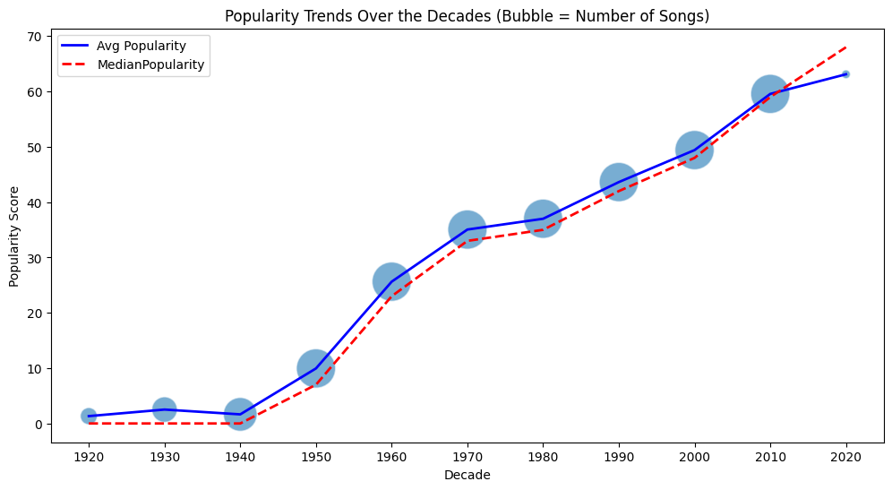

```python
# Create a new column for decades (e.g., 1990-1999, 2000-2009, etc.)
spotify_data['decade'] = (spotify_data['year'] // 10) * 10

# Group by decade and calculate avg popularity, median popularity, and song count
decade_trend = spotify_data.groupby('decade').agg(
    avg_popularity=('popularity', 'mean'),
    median_popularity=('popularity', 'median'),
    song_count=('popularity', 'count')
).reset_index()

# Set figure size
plt.figure(figsize=(12,6))

# Bubble Chart with Decade Binning
sns.scatterplot(data=decade_trend, x='decade', y='avg_popularity', size='song_count', sizes=(50, 1000), alpha=0.6, legend=False)

# Line plot to show the trend of average popularity
sns.lineplot(data=decade_trend, x='decade', y='avg_popularity', color='blue', linewidth=2, label='Avg Popularity')

# Line plot to show the trend of median popularity
sns.lineplot(data=decade_trend, x='decade', y='median_popularity', color='red', linewidth=2, linestyle='dashed', label='MedianPopularity')

# Labels and Title
plt.xlabel("Decade")
plt.ylabel("Popularity Score")
plt.title("Popularity Trends Over the Decades (Bubble = Number of Songs)")
plt.xticks(np.arange(decade_trend['decade'].min(), decade_trend['decade'].max() + 10, 10))  # Ensure proper decade labels
plt.show()
```

### **Correlation Analysis**

- Dependent variable - Popularity.
- Independent variable (numerical ones) - Acousticness, Danceability, Energy, Instrumentalness, Liveness, Loudness, Speechiness, Tempo, Valence.

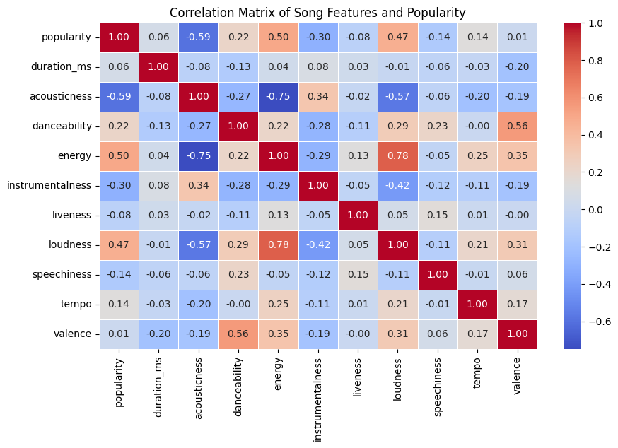

```python
# Selecting numerical columns for correlation analysis
correlation_features = [
    'popularity', 'duration_ms', 'acousticness', 'danceability', 'energy', 'instrumentalness',
    'liveness', 'loudness', 'speechiness', 'tempo', 'valence'
]

# Compute the correlation matrix
correlation_matrix = spotify_data[correlation_features].corr()

# Visualizing the correlation matrix as a heatmap
plt.figure(figsize=(10, 6))
sns.heatmap(correlation_matrix, annot=True, cmap='coolwarm', fmt=".2f", linewidths=0.5)

# Formatting the heatmap
plt.title("Correlation Matrix of Song Features and Popularity")
plt.show()
```

**From the heatmap, we can infer:**

- Highly danceable, energetic, and loud songs tend to be slightly more popular (moderate positive correlation).
- Acoustic and instrumental songs are less favored by listeners (negative correlation).
- Tempo and valence do not play a significant role in determining popularity (weak positive correlation, suggesting song speed or emotional positivity does not strongly determine success).
- Liveness and speech-heavy songs have minimal impact on popularity (weak/ neutral connection).

### **Categorical Variable Analysis**

- Track Key, Track Mode (Major/ Minor), and Explicitness (Whether or not the track has explicit lyrics)
- Frequency Distribution
- Comparing Explicitness and Mode with Popularity (T-Tests and Cohen's d)
- Comparing Key (12 values) with Popularity - (ANOVA with Eta-Squared)

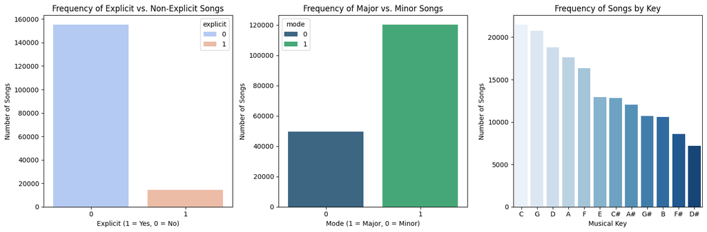

```python
# Frequency count for categorical variables
explicit_counts = spotify_data['explicit'].value_counts()
mode_counts = spotify_data['mode'].value_counts()
key_counts = spotify_data['key'].value_counts()

# Convert key numbers to note names (optional, for better readability)
key_mapping = {
    0: 'C', 1: 'C#', 2: 'D', 3: 'D#', 4: 'E', 5: 'F',
    6: 'F#', 7: 'G', 8: 'G#', 9: 'A', 10: 'A#', 11: 'B'
}
key_counts.index = key_counts.index.map(key_mapping)

# Plot frequency distributions
fig, axes = plt.subplots(1, 3, figsize=(15, 5))

# Explicit content distribution
sns.barplot(x=explicit_counts.index, y=explicit_counts.values, ax=axes[0], hue=explicit_counts.index, palette='coolwarm')
axes[0].set_title("Frequency of Explicit vs. Non-Explicit Songs")
axes[0].set_xlabel("Explicit (1 = Yes, 0 = No)")
axes[0].set_ylabel("Number of Songs")

# Mode distribution
sns.barplot(x=mode_counts.index, y=mode_counts.values, ax=axes[1], hue=mode_counts.index, palette="viridis")
axes[1].set_title("Frequency of Major vs. Minor Songs")
axes[1].set_xlabel("Mode (1 = Major, 0 = Minor)")
axes[1].set_ylabel("Number of Songs")

# Key distribution
sns.barplot(x=key_counts.index, y=key_counts.values, ax=axes[2], hue=key_counts.index, palette="Blues")
axes[2].set_title("Frequency of Songs by Key")
axes[2].set_xlabel("Musical Key")
axes[2].set_ylabel("Number of Songs")

plt.tight_layout()
plt.show()
```

```
 **T-Test for Popularity of Explicit vs. Non-Explicit Songs**
T-statistic: 85.236, P-value: 0.00000, Cohen's d: 0.763
Significant difference

 **T-Test for Popularity of Major vs. Minor Mode Songs**
T-statistic: -13.282, P-value: 0.00000, Cohen's d: -0.072
Significant difference

 **ANOVA Test for Popularity Across Musical Keys**
F-statistic: 197.178, P-value: 0.00000, Eta-Squared: 0.013
Significant difference
```

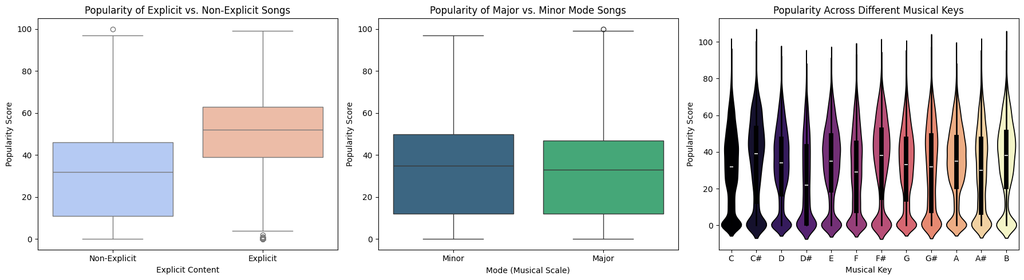

```python
from scipy.stats import ttest_ind, f_oneway
# T-Test: Explicit vs. Non-Explicit Songs
explicit_songs = spotify_data[spotify_data['explicit'] == 1]['popularity']
non_explicit_songs = spotify_data[spotify_data['explicit'] == 0]['popularity']
t_stat_explicit, p_value_explicit = ttest_ind(explicit_songs, non_explicit_songs, equal_var=False)

# Calculate Cohen’s d for effect size (T-Test)
cohen_d_explicit = (explicit_songs.mean() - non_explicit_songs.mean()) / np.sqrt(
    (explicit_songs.var() + non_explicit_songs.var()) / 2)

# T-Test: Major vs. Minor Mode Songs
major_songs = spotify_data[spotify_data['mode'] == 1]['popularity']
minor_songs = spotify_data[spotify_data['mode'] == 0]['popularity']
t_stat_mode, p_value_mode = ttest_ind(major_songs, minor_songs, equal_var=False)

# Calculate Cohen’s d for effect size (T-Test)
cohen_d_mode = (major_songs.mean() - minor_songs.mean()) / np.sqrt(
    (major_songs.var() + minor_songs.var()) / 2)

# ANOVA Test: Popularity Across Different Musical Keys
popularity_by_key = [spotify_data[spotify_data['key'] == k]['popularity'] for k in sorted(spotify_data['key'].unique())]
f_stat_key, p_value_key = f_oneway(*popularity_by_key)

# Calculate Eta-Squared for effect size (ANOVA)
ss_between = sum(len(group) * (group.mean() - spotify_data['popularity'].mean())**2 for group in popularity_by_key)
ss_total = sum((spotify_data['popularity'] - spotify_data['popularity'].mean())**2)
eta_squared = ss_between / ss_total  # Effect size for ANOVA

# Print All Test Results Together
print("\n **T-Test for Popularity of Explicit vs. Non-Explicit Songs**")
print(f"T-statistic: {t_stat_explicit:.3f}, P-value: {p_value_explicit:.5f}, Cohen's d: {cohen_d_explicit:.3f}")
print("Significant difference" if p_value_explicit < 0.05 else "No significant difference")

print("\n **T-Test for Popularity of Major vs. Minor Mode Songs**")
print(f"T-statistic: {t_stat_mode:.3f}, P-value: {p_value_mode:.5f}, Cohen's d: {cohen_d_mode:.3f}")
print("Significant difference" if p_value_mode < 0.05 else "No significant difference")

print("\n **ANOVA Test for Popularity Across Musical Keys**")
print(f"F-statistic: {f_stat_key:.3f}, P-value: {p_value_key:.5f}, Eta-Squared: {eta_squared:.3f}")
print("Significant difference" if p_value_key < 0.05 else "No significant difference")

# Visualizations of the three plots side by side
fig, axes = plt.subplots(1, 3, figsize=(18, 5))

# Explicit vs. Non-Explicit Popularity (Boxplot)
sns.boxplot(x=spotify_data['explicit'], y=spotify_data['popularity'], ax=axes[0], palette="coolwarm", hue=spotify_data['explicit'])
axes[0].set_xticks([0, 1])
axes[0].set_xticklabels(['Non-Explicit', 'Explicit'])
axes[0].set_xlabel("Explicit Content")
axes[0].set_ylabel("Popularity Score")
axes[0].set_title("Popularity of Explicit vs. Non-Explicit Songs")
axes[0].legend_.remove()  # Remove legend

# Major vs. Minor Mode Popularity (Boxplot)
sns.boxplot(x=spotify_data['mode'], y=spotify_data['popularity'], ax=axes[1], palette="viridis", hue=spotify_data['mode'])
axes[1].set_xticks([0, 1])
axes[1].set_xticklabels(['Minor', 'Major'])
axes[1].set_xlabel("Mode (Musical Scale)")
axes[1].set_ylabel("Popularity Score")
axes[1].set_title("Popularity of Major vs. Minor Mode Songs")
axes[1].legend_.remove()  # Remove legend

# Popularity Across Different Musical Keys (Violin Plot)
sns.violinplot(x=spotify_data['key'], y=spotify_data['popularity'], ax=axes[2], palette="magma", hue=spotify_data['key'])
axes[2].set_xlabel("Musical Key")
axes[2].set_ylabel("Popularity Score")
axes[2].set_title("Popularity Across Different Musical Keys")
axes[2].set_xticks(range(12))
axes[2].set_xticklabels(["C", "C#", "D", "D#", "E", "F", "F#", "G", "G#", "A", "A#", "B"])
axes[2].legend_.remove()  # Remove legend

plt.tight_layout()  # Adjust layout for better spacing
plt.show()
```